## Estimate true prevalence from individuals samples using multiple tests – conditional probability scheme

### Description

Bayesian estimation of true prevalence from apparent prevalence obtained by applying *multiple* tests to *individual* samples. `truePrevMulti` implements the approach described by Berkvens et al. (2006), which uses a multinomial distribution to model observed test results, and in which conditional dependence between tests is modelled through conditional probabilities.

### Usage

```r
truePrevMulti(x, n, prior, nchains = 2, burnin = 10000, update = 10000,
              verbose = FALSE)
```

### Arguments

| `x` | Vector of apparent test results; see ‘Details’ below |
| --- | --- |
| `n` | The total sample size |
| `prior` | The prior distribution for `theta`; see ‘Details’ below |
| `nchains` | The number of chains used in the estimation process; must be *2* |
| `burnin` | The number of discarded model iterations; defaults to 10,000 |
| `update` | The number of withheld model iterations; defaults to 10,000 |
| `verbose` | Logical flag, indicating if JAGS process output should be printed to the R console; defaults to `FALSE` |

### Details

`truePrevMulti` calls on [**JAGS**](http://mcmc-jags.sourceforge.net/) via the [**rjags**](https://cran.r-project.org/package=rjags) package to estimate true prevalence from apparent prevalence in a Bayesian framework. `truePrevMulti` fits a multinomial model to the apparent test results obtained by testing individual samples with a given number of tests. To see the actual fitted model, see the model slot of the `prev-class`-object.

The vector of apparent tests results, `x`, must contain the number of samples corresponding to each combination of test results. To see how this vector is defined for the number of tests `h` at hand, use `define_x`.

The values of `prior` can be specified in two ways, referred to as BUGS-style and list-style, respectively. See also below for some examples.

For BUGS-style specification, the values of `theta` should be given between curly brackets (i.e., `{}`), separated by line breaks. `theta` values can be specified to be deterministic (i.e., fixed), using the `<-` operator, or stochastic, using the `~` operator. In the latter case, the following distributions can be used:

- **Uniform:** `dunif(min, max)`
- **Beta:** `dbeta(alpha, beta)`
- **Beta-PERT:** `dpert(min, mode, max)`

Alternatively, `theta` values can be specified in a *named* `list()` as follows:

- **Fixed:** `list(dist = "fixed", par)`
- **Uniform:** `list(dist = "uniform", min, max)`
- **Beta:** `list(dist = "beta", alpha, beta)`
- **Beta-PERT:** `list(dist = "pert", method, a, m, b, k)`  
  `'method'` must be `"classic"` or `"vose"`;  
  `'a'` denotes the pessimistic (minimum) estimate, `'m'` the most likely estimate, and `'b'` the optimistic (maximum) estimate;  
  `'k'` denotes the scale parameter.  
  See `betaPERT` for more information on Beta-PERT parameterization.
- **Beta-Expert:** `list(dist = "beta-expert", mode, mean, lower, upper, p)`  
  `'mode'` denotes the most likely estimate, `'mean'` the mean estimate;  
  `'lower'` denotes the lower bound, `'upper'` the upper bound;  
  `'p'` denotes the confidence level of the expert.  
  Only `mode` or `mean` should be specified; `lower` and `upper` can be specified together or alone.  
  See `betaExpert` for more information on Beta-Expert parameterization.

### Value

A `prev-class` object.

### Note

Markov chain Monte Carlo sampling in `truePrevMulti` is performed by [**JAGS**](http://mcmc-jags.sourceforge.net/) (Just Another Gibbs Sampler) through the [**rjags**](https://cran.r-project.org/package=rjags) package. JAGS can be downloaded from http://sourceforge.net/projects/mcmc-jags/.

### References

- Berkvens D, Speybroeck N, Praet N, Adel A, Lesaffre E (2006) Estimating disease prevalence in a Bayesian framework using probabilistic constraints. *Epidemiology* **17**:145-153. http://dx.doi.org/10.1097/01.ede.0000198422.64801.8d
- Habib I, Sampers I, Uyttendaele M, De Zutter L, Berkvens D (2008) A Bayesian modelling framework to estimate *Campylobacter* prevalence and culture methods sensitivity: application to a chicken meat survey in Belgium. *J Appl Microbiol* **105**:2002-2008. http://dx.doi.org/10.1111/j.1365-2672.2008.03902.x
- Geurden T, Berkvens D, Casaert S, Vercruysse J, Claerebout E (2008) A Bayesian evaluation of three diagnostic assays for the detection of *Giardia duodenalis* in symptomatic and asymptomatic dogs. *Vet Parasitol* **157**:14-20. http://dx.doi.org/10.1016/j.vetpar.2008.07.002

### See Also

`define_x`: how to define the vector of apparent test results `x`

`define_prior`: how to define the vector of `theta` values in `prior`

[**coda**](https://cran.r-project.org/package=coda) for various functions that can be applied to the `prev@mcmc` object

`truePrevMulti2`: estimate true prevalence from apparent prevalence obtained by testing *individual* samples with multiple tests, using a covariance scheme

`truePrev`: estimate true prevalence from apparent prevalence obtained by testing *individual* samples with a single test

`truePrevPools`: estimate true prevalence from apparent prevalence obtained by testing *pooled* samples with a single test

`betaPERT`: calculate the parameters of a Beta-PERT distribution

`betaExpert`: calculate the parameters of a Beta distribution based on expert opinion

### Examples

```r
## ===================================================== ##
## 2-TEST EXAMPLE: Campylobacter                         ##
## ----------------------------------------------------- ##
## Two tests were performed on 656 chicken meat samples  ##
## -> T1 = enrichment culture                            ##
## -> T2 = direct plating                                ##
## The following assumption were made:                   ##
## -> TP is larger than 45% and smaller than 80%         ##
## -> SE1 must lie within 24% and 50%                    ##
## -> SP1 and SP2 both equal 100%                        ##
## -> beta(30, 12) describes P(T2+|D+,T1+)               ##
## The following results were obtained:                  ##
## -> 113 samples T1+,T2+                                ##
## ->  46 samples T1+,T2-                                ##
## -> 156 samples T1-,T2+                                ##
## -> 341 samples T1-,T2-                                ##
## ===================================================== ##

## how is the 2-test model defined?
define_x(2)
```

```
#> Definition of the apparent test results, 'x', for 2 tests:
#> x[1] : T1+,T2+
#> x[2] : T1+,T2-
#> x[3] : T1-,T2+
#> x[4] : T1-,T2-
```

```r
define_prior(2)
```

```
#> Conditional probability scheme
#> Definition of the prior, 'theta', for 2 tests:
#> theta[1] : P(D+) = TP
#> theta[2] : P(T1+|D+) = SE1
#> theta[3] : P(T1-|D-) = SP1
#> theta[4] : P(T2+|D+,T1+)
#> theta[5] : P(T2+|D+,T1-)
#> theta[6] : P(T2-|D-,T1-)
#> theta[7] : P(T2-|D-,T1+)
```

```r
## fit campylobacter 2-test model
campy <-
truePrevMulti(
  x = c(113, 46, 156, 341),
  n = 656,
  prior = {
    theta[1] ~ dunif(0.45, 0.80)
    theta[2] ~ dunif(0.24, 0.50)
    theta[3] <- 1
    theta[4] ~ dbeta(30, 12)
    theta[5] ~ dbeta(1, 1)
    theta[6] <- 1
    theta[7] <- 1
  }
)

## fit same model using 'list-style'
campy <-
truePrevMulti(
  x = c(113, 46, 156, 341),
  n = 656,
  prior =
    list(
      theta1 = list(dist = "uniform", min = 0.45, max = 0.80),
      theta2 = list(dist = "uniform", min = 0.24, max = 0.50),
      theta3 = 1,
      theta4 = list(dist = "beta", alpha = 30, beta = 12),
      theta5 = list(dist = "beta", alpha = 1, beta = 1),
      theta6 = 1,
      theta7 = 1
    )
)

## show model results
campy
```

```
#>      mean median  mode    sd  2.5% 97.5%
#>  TP 0.618  0.607 0.538 0.090 0.480 0.787
#> SE1 0.398  0.398 0.362 0.058 0.295 0.493
#> SP1 1.000  1.000 1.000 0.000 1.000 1.000
#> SE2 0.677  0.675 0.609 0.099 0.509 0.847
#> SP2 1.000  1.000 1.000 0.000 1.000 1.000
#>
#> Multivariate BGR statistic = 1.001
#> BGR values substantially above 1 indicate lack of convergence
#> Bayes-P statistic = 0.47
#> Bayes-P values substantially different from 0.5 indicate lack of convergence
```

```r
## explore model structure
str(campy)         # overall structure
```

```
#> Formal class 'prev' [package "prevalence"] with 4 slots
#>   ..@ par        :List of 7
#>   .. ..$ x      : num [1:4] 113 46 156 341
#>   .. ..$ n      : num 656
#>   .. ..$ prior  :List of 7
#>   .. .. ..$ :List of 2
#>   .. .. .. ..$ d: chr "uniform"
#>   .. .. .. ..$ p: num [1:2] 0.45 0.8
#>   .. .. ..$ :List of 2
#>   .. .. .. ..$ d: chr "uniform"
#>   .. .. .. ..$ p: num [1:2] 0.24 0.5
#>   .. .. ..$ :List of 2
#>   .. .. .. ..$ d: chr "fixed"
#>   .. .. .. ..$ p: num 1
#>   .. .. ..$ :List of 2
#>   .. .. .. ..$ d: chr "beta"
#>   .. .. .. ..$ p: num [1:2] 30 12
#>   .. .. ..$ :List of 2
#>   .. .. .. ..$ d: chr "beta"
#>   .. .. .. ..$ p: num [1:2] 1 1
#>   .. .. ..$ :List of 2
#>   .. .. .. ..$ d: chr "fixed"
#>   .. .. .. ..$ p: num 1
#>   .. .. ..$ :List of 2
#>   .. .. .. ..$ d: chr "fixed"
#>   .. .. .. ..$ p: num 1
#>   .. ..$ nchains: num 2
#>   .. ..$ burnin : num 10000
#>   .. ..$ update : num 10000
#>   .. ..$ inits  : NULL
#>   ..@ model      :Class 'prevModel'  chr [1:31] "model {" "x[1:4] ~ dmulti(AP[1:4], n)" "" "AP[1] <- theta[1]*theta[2]*theta[4] + (1-theta[1])*(1-theta[3])*(1-theta[7])" ...
#>   ..@ mcmc       :List of 6
#>   .. ..$ TP    :List of 2
#>   .. .. ..$ :Class 'mcmc'  atomic [1:10000] 0.632 0.602 0.605 0.618 0.549 ...
#>   .. .. .. .. ..- attr(*, "mcpar")= num [1:3] 11001 21000 1
#>   .. .. ..$ :Class 'mcmc'  atomic [1:10000] 0.637 0.643 0.696 0.737 0.735 ...
#>   .. .. .. .. ..- attr(*, "mcpar")= num [1:3] 11001 21000 1
#>   .. .. ..- attr(*, "class")= chr "mcmc.list"
#>   .. ..$ SE1   :List of 2
#>   .. .. ..$ :Class 'mcmc'  atomic [1:10000] 0.399 0.406 0.405 0.362 0.409 ...
```

[output cut: 29 more lines]

```
#>   .. ..$ DIC   :List of 3
#>   .. .. ..$ deviance:Class 'mcarray'  Named num 21.2
#>   .. .. .. .. ..- attr(*, "names")= chr "x"
#>   .. .. ..$ penalty :Class 'mcarray'  Named num 2.67
#>   .. .. .. .. ..- attr(*, "names")= chr "x"
#>   .. .. ..$ type    : chr "pD"
#>   .. .. ..- attr(*, "class")= chr "dic"
#>   .. ..$ BGR   :List of 2
#>   .. .. ..$ psrf : num [1:3, 1:2] 1 1 1 1 1 ...
#>   .. .. .. ..- attr(*, "dimnames")=List of 2
#>   .. .. .. .. ..$ : chr [1:3] "SE1" "SE2" "TP"
#>   .. .. .. .. ..$ : chr [1:2] "Point est." "Upper C.I."
#>   .. .. ..$ mpsrf: num 1
#>   .. .. ..- attr(*, "class")= chr "gelman.diag"
#>   .. ..$ bayesP: num 0.466
```

```r
str(campy@par)     # structure of slot 'par'
```

```
#> List of 7
#>  $ x      : num [1:4] 113 46 156 341
#>  $ n      : num 656
#>  $ prior  :List of 7
#>   ..$ :List of 2
#>   .. ..$ d: chr "uniform"
#>   .. ..$ p: num [1:2] 0.45 0.8
#>   ..$ :List of 2
#>   .. ..$ d: chr "uniform"
#>   .. ..$ p: num [1:2] 0.24 0.5
#>   ..$ :List of 2
#>   .. ..$ d: chr "fixed"
#>   .. ..$ p: num 1
#>   ..$ :List of 2
#>   .. ..$ d: chr "beta"
#>   .. ..$ p: num [1:2] 30 12
#>   ..$ :List of 2
#>   .. ..$ d: chr "beta"
#>   .. ..$ p: num [1:2] 1 1
#>   ..$ :List of 2
#>   .. ..$ d: chr "fixed"
#>   .. ..$ p: num 1
#>   ..$ :List of 2
#>   .. ..$ d: chr "fixed"
#>   .. ..$ p: num 1
#>  $ nchains: num 2
#>  $ burnin : num 10000
#>  $ update : num 10000
#>  $ inits  : NULL
```

```r
str(campy@mcmc)    # structure of slot 'mcmc'
```

```
#> List of 6
#>  $ TP    :List of 2
#>   ..$ :Class 'mcmc'  atomic [1:10000] 0.632 0.602 0.605 0.618 0.549 ...
#>   .. .. ..- attr(*, "mcpar")= num [1:3] 11001 21000 1
#>   ..$ :Class 'mcmc'  atomic [1:10000] 0.637 0.643 0.696 0.737 0.735 ...
#>   .. .. ..- attr(*, "mcpar")= num [1:3] 11001 21000 1
#>   ..- attr(*, "class")= chr "mcmc.list"
#>  $ SE1   :List of 2
#>   ..$ :Class 'mcmc'  atomic [1:10000] 0.399 0.406 0.405 0.362 0.409 ...
#>   .. .. ..- attr(*, "mcpar")= num [1:3] 11001 21000 1
#>   ..$ :Class 'mcmc'  atomic [1:10000] 0.377 0.399 0.388 0.306 0.301 ...
#>   .. .. ..- attr(*, "mcpar")= num [1:3] 11001 21000 1
#>   ..- attr(*, "class")= chr "mcmc.list"
#>  $ SP1   :List of 2
#>   ..$ :Class 'mcmc'  atomic [1:10000] 1 1 1 1 1 1 1 1 1 1 ...
#>   .. .. ..- attr(*, "mcpar")= num [1:3] 11001 21000 1
#>   ..$ :Class 'mcmc'  atomic [1:10000] 1 1 1 1 1 1 1 1 1 1 ...
#>   .. .. ..- attr(*, "mcpar")= num [1:3] 11001 21000 1
#>   ..- attr(*, "class")= chr "mcmc.list"
#>  $ SE2   :List of 2
#>   ..$ :Class 'mcmc'  atomic [1:10000] 0.66 0.649 0.729 0.646 0.674 ...
#>   .. .. ..- attr(*, "mcpar")= num [1:3] 11001 21000 1
#>   ..$ :Class 'mcmc'  atomic [1:10000] 0.659 0.649 0.626 0.595 0.5 ...
#>   .. .. ..- attr(*, "mcpar")= num [1:3] 11001 21000 1
#>   ..- attr(*, "class")= chr "mcmc.list"
#>  $ SP2   :List of 2
#>   ..$ :Class 'mcmc'  atomic [1:10000] 1 1 1 1 1 1 1 1 1 1 ...
#>   .. .. ..- attr(*, "mcpar")= num [1:3] 11001 21000 1
#>   ..$ :Class 'mcmc'  atomic [1:10000] 1 1 1 1 1 1 1 1 1 1 ...
#>   .. .. ..- attr(*, "mcpar")= num [1:3] 11001 21000 1
#>   ..- attr(*, "class")= chr "mcmc.list"
#>  $ bayesP:List of 2
#>   ..$ :Class 'mcmc'  atomic [1:10000] 1 0 1 0 1 0 0 0 0 1 ...
#>   .. .. ..- attr(*, "mcpar")= num [1:3] 11001 21000 1
#>   ..$ :Class 'mcmc'  atomic [1:10000] 1 0 1 1 1 1 1 1 0 0 ...
#>   .. .. ..- attr(*, "mcpar")= num [1:3] 11001 21000 1
#>   ..- attr(*, "class")= chr "mcmc.list"
```

```r
campy@model        # fitted model
```

```
#> model {
#>   x[1:4] ~ dmulti(AP[1:4], n)
#>
#>   AP[1] <- theta[1]*theta[2]*theta[4] + (1-theta[1])*(1-theta[3])*(1-theta[7])
#>   AP[2] <- theta[1]*theta[2]*(1-theta[4]) + (1-theta[1])*(1-theta[3])*theta[7]
#>   AP[3] <- theta[1]*(1-theta[2])*theta[5] + (1-theta[1])*theta[3]*(1-theta[6])
#>   AP[4] <- theta[1]*(1-theta[2])*(1-theta[5]) + (1-theta[1])*theta[3]*theta[6]
#>
#>   theta[1] ~ dunif(0.45, 0.8)
#>   theta[2] ~ dunif(0.24, 0.5)
#>   theta[3] <- 1
#>   theta[4] ~ dbeta(30, 12)
#>   theta[5] ~ dbeta(1, 1)
#>   theta[6] <- 1
#>   theta[7] <- 1
#>
#>   x2[1:4] ~ dmulti(AP[1:4], n)
#>   for (i in 1:4) {
#>     d1[i] <- x[i] * log(max(x[i],1) / (AP[i]*n))
#>     d2[i] <- x2[i] * log(max(x2[i],1) / (AP[i]*n))
#>   }
#>   G0 <- 2 * sum(d1[])
#>   Gt <- 2 * sum(d2[])
#>   bayesP <- step(G0 - Gt)
#>
#>   TP <- theta[1]
#>   SE1 <- theta[2]
#>   SP1 <- theta[3]
#>   SE2 <- theta[2] * theta[4] + (1-theta[2]) * theta[5]
#>   SP2 <- theta[3] * theta[6] + (1-theta[3]) * theta[7]
#> }
```

```r
campy@diagnostics  # DIC, BGR and Bayes-P values
```

```
#> $DIC
#> Mean deviance:  21.17
#> penalty 2.672
#> Penalized deviance: 23.84
#>
#> $BGR
#> Potential scale reduction factors:
#>
#>     Point est. Upper C.I.
#> SE1          1          1
#> SE2          1          1
#> TP           1          1
#>
#> Multivariate psrf
#>
#> 1
#>
#> $bayesP
#> [1] 0.46595
```

```r
## standard methods
print(campy)
```

```
#>      mean median  mode    sd  2.5% 97.5%
#>  TP 0.618  0.607 0.538 0.090 0.480 0.787
#> SE1 0.398  0.398 0.362 0.058 0.295 0.493
#> SP1 1.000  1.000 1.000 0.000 1.000 1.000
#> SE2 0.677  0.675 0.609 0.099 0.509 0.847
#> SP2 1.000  1.000 1.000 0.000 1.000 1.000
#>
#> Multivariate BGR statistic = 1.001
#> BGR values substantially above 1 indicate lack of convergence
#> Bayes-P statistic = 0.47
#> Bayes-P values substantially different from 0.5 indicate lack of convergence
```

```r
summary(campy)
```

```
#> $TP
#>                 mean    median      mode         sd         var      2.5%
#> chain 1    0.6199229 0.6078247 0.5368791 0.09150965 0.008374015 0.4812390
#> chain 2    0.6158595 0.6061822 0.5360000 0.08914862 0.007947477 0.4787141
#> all chains 0.6178912 0.6070227 0.5375477 0.09035743 0.008164466 0.4802267
#>                97.5% samples
#> chain 1    0.7873944   10000
#> chain 2    0.7867800   10000
#> all chains 0.7871350   20000
#>
#> $SE1
#>                 mean    median      mode         sd         var      2.5%
#> chain 1    0.3969175 0.3974266 0.4507818 0.05872172 0.003448240 0.2934889
#> chain 2    0.3986561 0.3993997 0.3954451 0.05691255 0.003239038 0.2954941
#> all chains 0.3977868 0.3984066 0.3617115 0.05782930 0.003344227 0.2945072
#>                97.5% samples
#> chain 1    0.4932038   10000
#> chain 2    0.4931574   10000
#> all chains 0.4931970   20000
#>
#> $SP1
#>            mean median mode sd var 2.5% 97.5% samples
#> chain 1       1      1    1  0   0    1     1   10000
#> chain 2       1      1    1  0   0    1     1   10000
#> all chains    1      1    1  0   0    1     1   20000
#>
#> $SE2
#>                 mean    median      mode         sd         var      2.5%
#> chain 1    0.6749214 0.6738424 0.6107965 0.09985975 0.009971970 0.5092623
#> chain 2    0.6781265 0.6771043 0.6639961 0.09719916 0.009447677 0.5086821
#> all chains 0.6765239 0.6754320 0.6089149 0.09854900 0.009711906 0.5090104
#>                97.5% samples
#> chain 1    0.8473936   10000
#> chain 2    0.8461685   10000
#> all chains 0.8468951   20000
#>
#> $SP2
#>            mean median mode sd var 2.5% 97.5% samples
#> chain 1       1      1    1  0   0    1     1   10000
#> chain 2       1      1    1  0   0    1     1   10000
#> all chains    1      1    1  0   0    1     1   20000
```

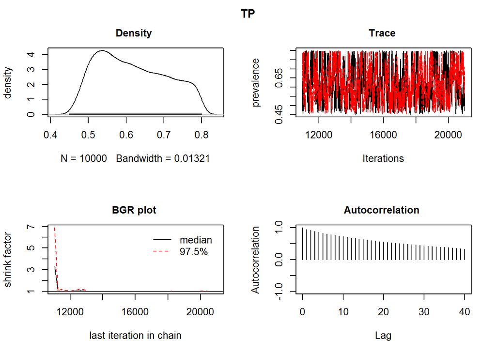

```r
par(mfrow = c(2, 2))
plot(campy)         # shows plots of TP by default
```

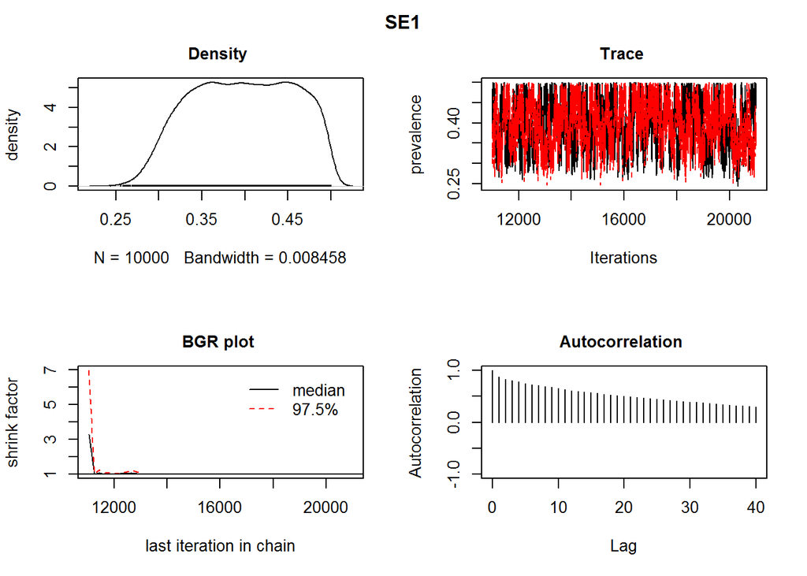

```r
plot(campy, "SE1")  # same plots for SE1
```

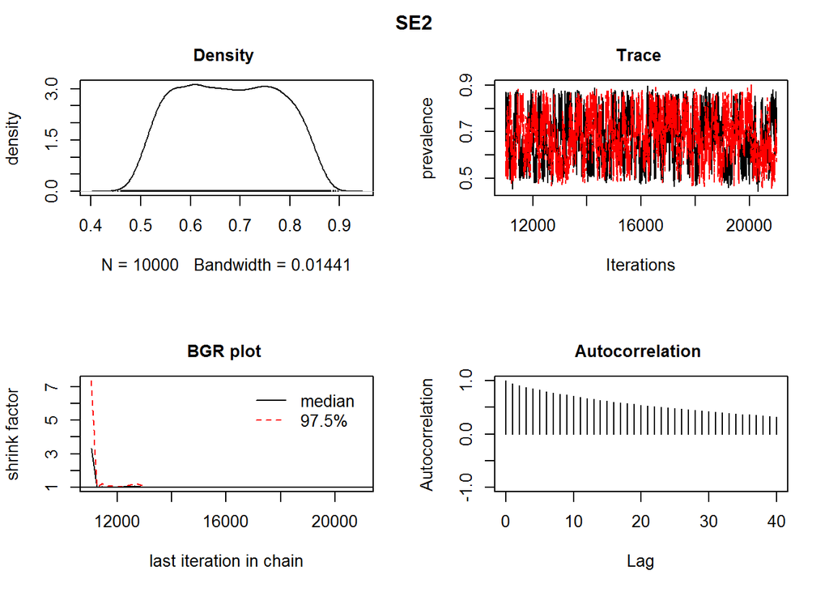

```r
plot(campy, "SE2")  # same plots for SE2
```

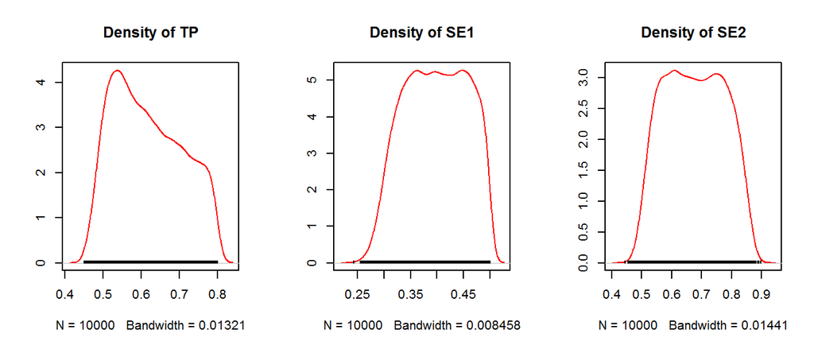

```r
## coda plots of TP, SE1, SE2
par(mfrow = c(1, 3))
densplot(campy, col = "red")
```